# EPI 563 Final Project - Group 16

Spatial Pattern of AIDS Incidence in China in 2018, and its Association with Education and Healthcare

Holin Chen & Shiyun Qin

# 1. Objectives

- Is there province-level spatial heterogeneity or autocorrelation of AIDS incidence rate in China in 2018?
- Is the spatial pattern of AIDS incidence rate associated with the spatial variety of education level and healthcare resources?

# 2. Set up

## 2.1 Packages

```r
library(sf)       # For management of sf data
library(dplyr)    # For data manipulation
library(spdep)    # Functions for creating spatial weight, spatial analysis, probability mapping
library(DCluster) # Package with functions for spatial cluster analysis
library(tmap)     # For mapping
library(ggplot2)  # For making various plots
## The package below are used for bivariate maps (The tutorial I referred used)
library(viridis)  # Viridis color scale
library(cowplot)  # stack ggplots
library(tidyr)    # Manipulate string data
```

## 2.2 Attribute Data

### 2.2.1 Import Data

```r
# Load Attribute Data-----------
health.raw <- read.csv("Data/HIV-2018_Raw.csv")
summary(health.raw)
edu.raw <- read.csv("Data/Education-2018_Raw.csv")
summary(edu.raw)
tw <- read.csv("Data/TW_HK_MC.csv")
```

### 2.2.2 Data Dictionary

#### **`HIV-2018_Raw.csv`**

The data in this dataset were collected from China Health Statistical Yearbook, National Health Commission of the PRC, 2019. It only contains AIDS incidence rate, and we decided to calculate the disease count based on:
$$Disease count = Incidence rate * Population / 100,000$$
*(noted in the appendix)*

| Variable | Defination | Source |
| --- | --- | --- |
| `PROVINCE` | Province Name (The first row is country-level, **# of province (n) = 31**) | China Health Statistical Yearbook, 2019 |
| `ADM1_PCODE` | Province Code (Match with the Geography data) | China Administrative Boundary |
| `POP` | Estimated population in 2018 (in 10,000) (Country-wide census was performed in China for each 10 years, the population count in 2018 was estimated) | Table 14-4. Total population by province |
| `RATE` | AIDS Incidence Rate in 2018 (1 / 100,000 person) | Table 10-1-4. Incidence and death rate of Class A and B legally reported infectious diseases by province in 2018 (Continued Table 2) |
| `HEALTHCARE` | Total number of Healthcare Institutions in 2018 | Table 1-1-2. Number of healthcare institutions by province in 2018 |
| `POP_DENSITY` | Population density in 2000 (person / km^2) | Table 14-8. Gender ratio, population density and dependency ratio by province |
| `GDP` | GDP in 2018 (in 100 million Yuan) | Appendex 1-2-2. GDP and general public budget revenue and expenditure by province in 2018 |
| `GDP_CAPITAL` | GDP per capita in 2018 (in Yuan) | Appendex 1-2-2. GDP and general public budget revenue and expenditure by province in 2018 |

#### **`Education-2018_Raw.csv`**

The data in this dataset were collected from China Statistical Yearbook, National Bureau of Statistics of China, 2019. Table 2-14. Population aged 6 and above by sex and level of education by province in 2018. *This is a sample data; the sampling ratio is 0.820‰.*

| Variable | Defination |
| --- | --- |
| `PROVINCE` | Province Name (The first row is country-level, # of province = 31) (Match with `HIV-2018_Raw.csv`) |
| `合计 (Total)` | Total number of surveyed people (count) |
| `高中 (High school)` | Total number of surveyed people whose highest education level is high school (count) |
| `大学专科 (Three -year college)` | Total number of surveyed people whose highest education level is three-year college (count) |
| `大学本科 (Bachelor)` | Total number of surveyed people whose highest education level is bachelor’s degree (count) |
| `研究生 (Postgraduate)` | Total number of surveyed people whose highest education level is postgraduate (count) |

#### **`TW_HK_MC.csv`**

This dataset contains population and case number of AIDS in Taiwan, Hong Kong and Macau, retrieved from Bureau of Statistics of these regions. Other covariates were not collected for these three regions, so these data will be missing in correlation analysis.

| Variable | Defination |
| --- | --- |
| `PROVINCE` | Province Name |
| `ADM1_PCODE` | Province Code (Match with the Geography data) |
| `POP` | Estimated population in 2018 (in 10,000) |
| `CASE` | AIDS cases in 2018 (in 10,000) |

*All data above were manually collected and translated.*

### 2.2.3 Data Manipulation

In this step, we did:

- Create **`EDUCATION`** variable use data from `Education-2018_Raw.csv`. **`EDUCATION`** is the percentage of population with high school degree or above (High school, Three-year college, Bachelor and Postgraduate). We use this variable to estimate the average education level in each province.
- Clean `health` dataset. We create **`CASE`** variable, which is calculated based on `POP` and `RATE`. Then we add **`EDUCATION`** into `health` dataset.
- Calculat rate in `tw` dataset based on `POP` and `CASES`, then add to `health` dataset.
- Draw histograms for `RATE` and `EDUCATION` to check their distribution.

```r
# Manipulate data----------
# Create EDUCATION
edu <- edu.raw %>%
  mutate(EDUCATION = round((高中+大学专科+大学本科+研究生)/合计 * 100,2))
# Clean health dataset and add new variables
health <- health.raw %>%
  mutate(CASE = round(POP * (RATE/10))) %>%
  left_join(edu[, c("PROVINCE", "EDUCATION")], by = "PROVINCE")
# Clean tw dataset
tw$RATE <- round(tw$CASE * 10 / tw$POP,2)
# Add back to health
health[33:35,c("PROVINCE", "ADM1_PCODE", "POP", "RATE", "CASE")] <- tw[,c("PROVINCE", "ADM1_PCODE", "POP", "RATE", "CASE")]

# Summary and histograms (results are hided)
summary(health)
# hist(health$RATE)  # Right-skewed
# hist(health$EDUCATION)  # Almost normal
```

## 2.3 Geography Data

### 2.3.1 Import Data

```r
# Load Geography Data--------
province <- st_read("Data/chn_adm_ocha_2020_shp/chn_admbnda_adm1_ocha_2020.shp") %>%
  dplyr::select(ADM1_EN, ADM1_ZH, ADM1_PCODE) # remove variables that will not be used
# Summary and check data (results are hided)
summary(province)
class(province)
st_crs(province)
```

### 2.3.2 Data Dictionary

#### **`chn_province.shp`**

The geodata were downloaded from China Administrative Boundary Common Operational Database from OCHA (United Nations Office for the Coordination of Humanitarian Affairs). We only use province-level data for this study.

| Variable | Defination |
| --- | --- |
| `ADM1_EN` | Province name in English |
| `ADM1_ZH` | Province name in Chinese |
| `ADM1_PCODE` | Provice code |
| `geometry` | `sf` geometry column |

## 2.4 Combine Attribute Data with Geodata

```r
# Combine Attribute Data with Geodata
hiv <- province %>% left_join(health, by = "ADM1_PCODE")

summary(health)
# I checked HEALTHCARE here, because, the national level was also included in health dataset, which for this variable is the total number of all the healthcare facilities in China
# hist(hiv$HEALTHCARE)  # Normal?
```

# 3. Aspatial Descriptive Mapping

In this project, we focus on three variables: + Outcome: `RATE` (also use `POP` and `CASE` in some analysis) + Coviarients: `EDUCATION` (average edu level), `HEALTHCARE` (count of healthcare institutions)

In this step, we put each variable into map to make three aspatial descriptive map. It is helpful for people to unserstand the distribution of data, and have a general idea of our project. `tmap` package is used in this step.

## 3.1 Descriptive map for `RATE`

```r
rate0 <- health %>%
  dplyr::filter(RATE < 10) %>%  # Exclude provinces with rate higher than 10
  dplyr::filter(!ADM1_PCODE == "CN") %>%  # The first line is national level, so we exclude it here
  dplyr::select(RATE, POP, CASE)
summary(rate0$RATE)
```

```
   Min. 1st Qu.  Median    Mean 3rd Qu.    Max.
  0.960   1.840   2.295   2.581   3.058   5.520
```

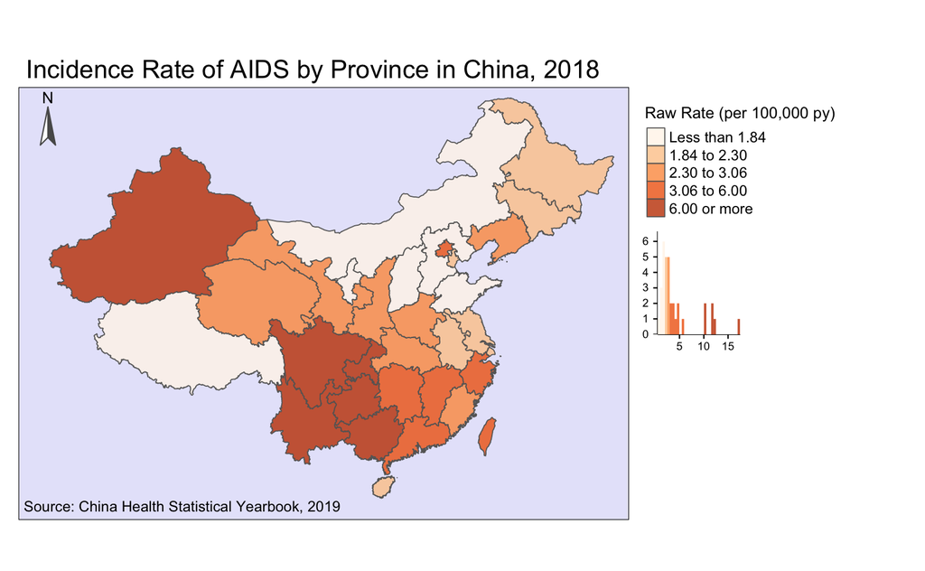

```r
# Descriptive map by just mapping the incidence rate
tm_shape(hiv) +
  tm_fill('RATE',
          style="fixed",
          breaks = c(-Inf, 1.84, 2.30, 3.06, 6, +Inf),
          palette = 'Oranges',
          alpha = 0.8,
          title = 'Raw Rate (per 100,000 py)',
          legend.hist = T)+ # include a tiny histgram here to see if data are grouped reasonably
  tm_borders(lwd = 0.8) +
  tm_credits('Source: China Health Statistical Yearbook, 2019',
             size = 0.7,
             position = c('LEFT','BOTTOM')) +
  tm_layout(main.title = 'Incidence Rate of AIDS by Province in China, 2018',
            main.title.size = 1.2,
            inner.margins = c(.05,0.05,0.025,0.025),
            legend.title.size = 0.9 ,
            bg.color = 'lavender',
            legend.outside = T) +
  tm_compass(position = c('LEFT','TOP'),
             text.size = 0.75,
             color.dark = "grey35")
```

- The mean of raw rate is 4.29 (lower than country-level average, indicates significant outliers)
- Min.: 0.96 (Shandong); Max. = 17.47 (Sichuan)
- South-West and Xinjiang (North-West) seems to have higher incidence rates of AIDS than other provinces

## 3.2 Descriptive map for `EDUCATION`

We used `style = "fisher"` option for this map, due to small sample size.

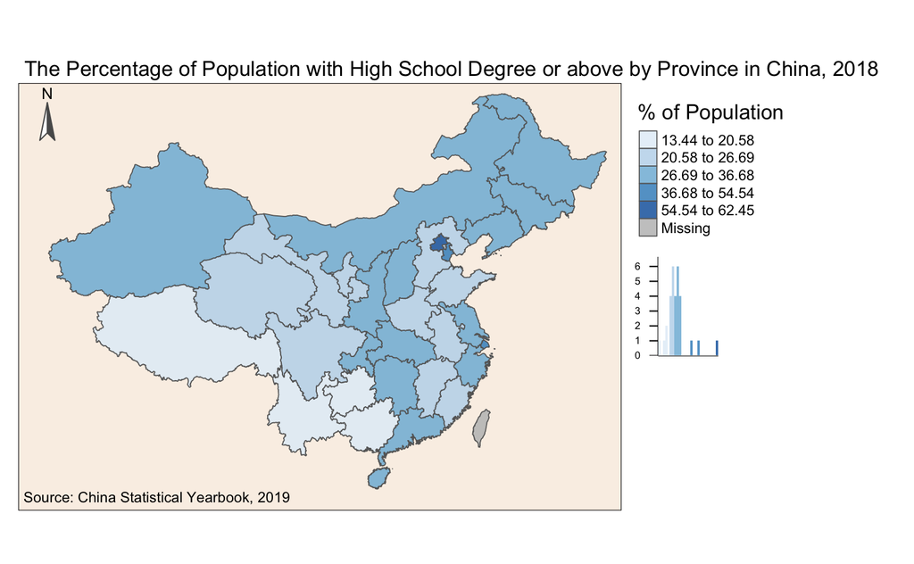

```r
# Map for EDUCATION
tm_shape(hiv) +
  tm_fill('EDUCATION',
          style="fisher",
          palette = 'Blues',
          alpha = 0.85,
          title = '% of Population',
          legend.hist = T)+
  tm_borders(lwd = 0.8) +
  tm_credits('Source: China Statistical Yearbook, 2019',
             size = 0.7,
             position = c('LEFT','BOTTOM')) +
  tm_layout(main.title = 'The Percentage of Population with High School Degree or above by Province in China, 2018',
            main.title.size = 1,
            inner.margins = c(.05,0.05,0.025,0.025),
            legend.title.size = 1.2,
            bg.color = 'linen',
            legend.hist.size = 1.4,
            legend.outside = T) +
  tm_compass(position = c('LEFT','TOP'),
             text.size = 0.75,
             color.dark = "grey35")
```

- The average education level is 27.99%. Min.: 13.44% (Tibet). Max. = 62.45%. Missing = 3.
- The highest education level is in Beijing (62.45%), which is the capital of China, and it is far more higher than the average
- The provinces in Eastern China seems to have higher percentage of people with high school degree or above than those in Western China (especially South-west)

## 3.3 Descriptive map for `HEALTHCARE`

Because of small sample size, we also used `style = "fisher"` option for this map.

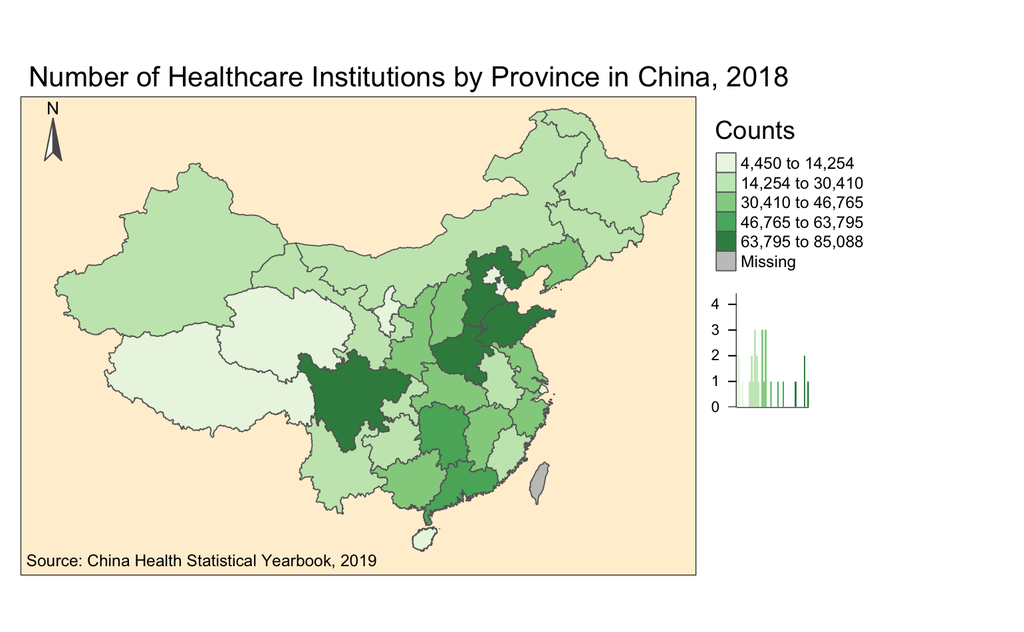

```r
# Map for HEALTHCARE
tm_shape(hiv) +
  tm_fill('HEALTHCARE',
          style="fisher",
          palette = 'Greens',
          alpha = 0.9,
          title = 'Counts',
          legend.hist = T)+
  tm_borders(lwd = 0.8) +
  tm_credits('Source: China Health Statistical Yearbook, 2019',
             size = 0.7,
             position = c('LEFT','BOTTOM')) +
  tm_layout(main.title = 'Number of Healthcare Institutions by Province in China, 2018',
            main.title.size = 1.2,
            inner.margins = c(.05,0.05,0.025,0.025),
            legend.title.size = 1.3,
            bg.color = 'papayawhip',
            legend.hist.size = 1.2,
            legend.outside = T) +
  tm_compass(position = c('LEFT','TOP'),
             text.size = 0.75,
             color.dark = "grey35")
```

# 4. Disease Mapping (Spatial Heterogeneity)

This step is in order to answer the first question, whether there is province-level spatial heterogeneity of AIDS incidence rate in China in 2018, we firstly performed a chi-square good-of-fit test. The global test turned out to be statistically significant, so we proceed to do disease mapping. Excess risk and precision are described by mapping SMR with Poisson Probability Map results, using un-adjusted raw rates.

## 4.1 Chi-square good-of-fit test

This step is to answer the question: In the global level, is there any evidence of spatial heterogeneity?

```r
# Calculate the expected count
# Calculate the nation-wide average rate
avg_rate <- sum(hiv$CASE) / sum(hiv$POP) * 10

# Calculate SMR and expected case count
hiv <- hiv %>%
  mutate(smr = round(RATE / avg_rate, 2),
         expected = (avg_rate / 10) * POP)
# hist(hiv$smr) # Check the distribution

# Test for homogeneity
achisq.test(CASE ~ offset(log(expected)),
            data = hiv,
            model = 'poisson', # because AIDS is a rare disease, we use poisson distribution here
            R = 499)
```

```
Chi-square test for overdispersion

    Type of boots.: parametric
    Model used when sampling: Poisson
    Number of simulations: 499
    Statistic:  61939.44
    p-value :  0.002
```

```r
# Chi-square = 61939.44 , p-value = 0.002
```

p-value < 0.01, there is statistically significant evidence that the rate of AIDS varies geographically in China. Then we move on to Disease Mapping using SMR to see in which area, the rate (/risk) is higher.

## 4.2 SMR map with Poisson Probability Map results, using unadjusted raw rates

For this step, we map SMR to examine in which area, the rate (/risk) is higher. We also perform a Poisson Probability Mapping order to describe the precision (e.g. if it is due to small sample size). The function `probmap` from the package `spdep` does this using a one-tailed test contrasting the number of events to the population at risk.

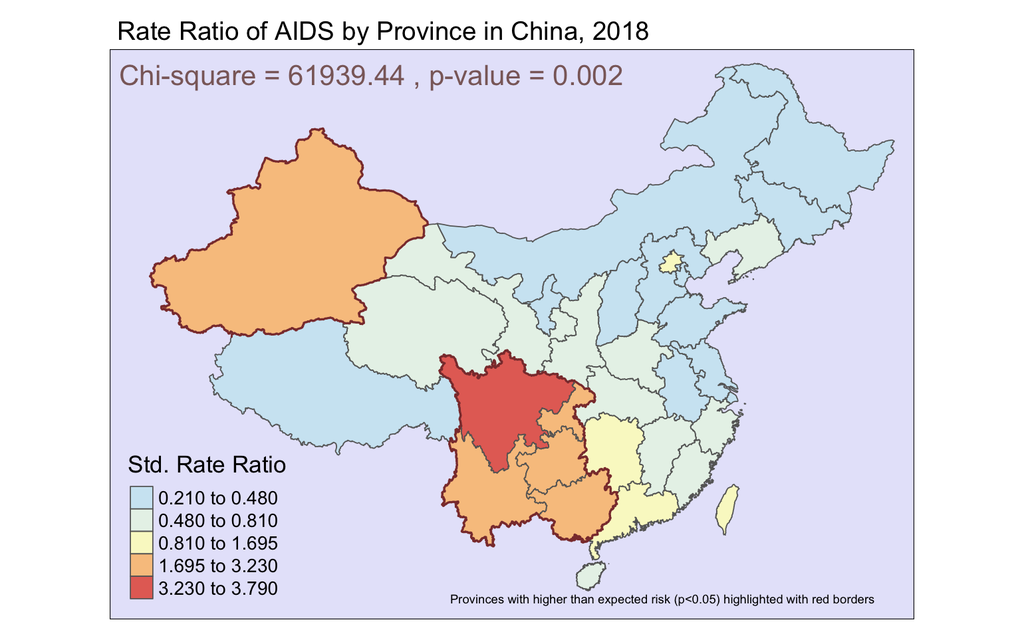

```r
# Poisson probability map
x <- probmap(n = hiv$CASE, x = hiv$POP,
             alternative = 'greater')
hiv$pmap <- x$pmap

# Combine the p-value result with SMR data
# Group significant regions together
pv <- hiv %>%
  mutate(pmap.pv = ifelse(smr > 1 & pmap < 0.05, 1, 0)) %>%
  group_by(pmap.pv) %>%
  summarise() %>%
  filter(pmap.pv == 1)

# SMR map with probability, using raw rate
tm_shape(hiv) +
  tm_fill('smr',
          style="fisher",
          palette = '-RdYlBu',
          alpha = 0.8,
          title = 'Std. Rate Ratio')+
  tm_borders(lwd = 0.8) +
  tm_credits('Provinces with higher than expected risk (p<0.05) highlighted with red borders',
             size = 2,
             position = c('LEFT','BOTTOM')) +
  tm_layout(main.title = 'Rate Ratio of AIDS by Province in China, 2018',
            main.title.size = 1.1,
            inner.margins = c(.05,0.05,0.025,0.025),
            legend.text.size = 0.8,
            legend.title.size = 1.2,
            bg.color = 'lavender') +
  tm_shape(pv) +
  tm_borders(lwd = 1.5, col = 'indianred4') +
  # Add chi-square test result to the plot, make the plot more informative
  tm_credits("Chi-square = 61939.44 , p-value = 0.002",
             size = 1.2,
             col = "rosybrown4",
             position = c('LEFT','TOP'))
```

# 5. Moran’s I test and LISA Cluster Map (Spatial Dependence)

Global Moran’s test is used to see if there is any spatial autocorrelation of Rates (answer the second part of the first question). After confirming the existence of spatial heterogeneity (p-value for Moran’s test < 0.001), we create the cluster map of AIDS incidence rate by using the **exact** Local Indicators of Spatial Association (LISA) statistics method to see where the cluster(s) of high and low incident AIDS rate locates. In order to conduct the LISA test, we decided to use queen contiguity method to define neighbors for each province, because we think the area of most provinces are too wide, regions without sharing boundaries are hard to affect each other. For two islands (Hainan and Taiwan), we manually added Guangdong and Fujian as their neighbors.

## 5.1 Moran’s I test

This step is to perform a test of global spatial auto-correlation, which answers the question whether there is spatial dependence

```r
# Define neighbors
qnb <- poly2nb(hiv)
# Because Hainan and Taiwan are islands, they do not share boundaries with other provinces,
# we decide to manually add neighbors for them according to administrative division
qnb[[34]] <- as.integer(30) # Hainan: Guangdong
qnb[[27]] <- as.integer(31) # Taiwan: Fujian
q_listw <- nb2listw(qnb, style = 'W')

# Because these rate data are not normally distributed, we choose the randomisation = T option
moran.test(hiv$RATE,
           listw = q_listw,
           randomisation = T)
```

```
    Moran I test under randomisation

data:  hiv$RATE
weights: q_listw

Moran I statistic standard deviate = 3.4771, p-value = 0.0002534
alternative hypothesis: greater
sample estimates:
Moran I statistic       Expectation          Variance
       0.36683398       -0.03030303        0.01304481
```

```r
# Moran's I: 0.367, p-value = 0.00025 < 0.05
# There is significant positive spatial autocorrelation
```

## 5.2 LISA Cluster Map

LISA map is a local test to find out where the clusters are. This method does not account for the Poisson distribution, instead making assumptions that the raw rate is normally distributed with equal variance. Because our sample size is small (n=34), we decide to use exact test, so that each province is being compared to a very small number of other provinces. For visualization, the results are grouped into five categories *(High-High. Low-Low, High-Low, Low-High and Non-significant)*.

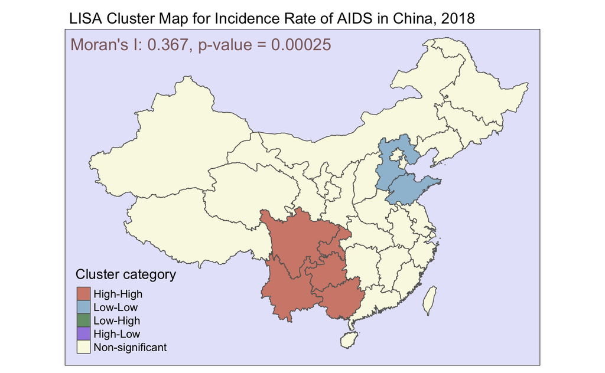

```r
# Use linear regression to account for the difference in population-at-risk
# Create weights for each observation
wts <- hiv$POP / sum(hiv$POP) * 34
# Create a linear regression model
reg1 <- lm(RATE ~ 1,
           data = hiv,
           weights = wts)

lm <- localmoran.exact(reg1, nb = qnb)
lm <- print(lm)
hiv$pvalExact <- lm[,3]

# create lagged local raw_rate - in other words the average of the queen neighbors value
hiv$lag <- lag.listw(q_listw, var = hiv$RATE)

# Create a new dataset that includes standardized values, and then creates a new variable
# 'lm_quad' which takes on the above categorical values.
hiv_lm <- hiv %>%
  mutate(raw_std = as.numeric(scale(RATE)), # scale means standardize to mean 0, 1 SD
         lag_std = as.numeric(scale(lag)),
         lm_quad = factor(case_when(  # All of this is assigning labels based on values
           raw_std >= 0 & lag_std >= 0 & pvalExact < 0.05 ~ 'High-High',
           raw_std <= 0 & lag_std <= 0 & pvalExact < 0.05 ~ 'Low-Low',
           raw_std <= 0 & lag_std >= 0 & pvalExact < 0.05 ~ 'Low-High',
           raw_std >= 0 & lag_std <= 0 & pvalExact < 0.05 ~ 'High-Low',
           pvalExact >= 0.05 ~ 'Non-significant'),
           levels = c('High-High','Low-Low','Low-High','High-Low','Non-significant')))

# Plot
tm_shape(hiv_lm) +
  tm_fill('lm_quad',
          style = 'cat',
          palette = c("salmon3", "lightskyblue3", "palegreen4", "mediumpurple", "lightyellow"),
          alpha = 0.8,
          title = 'Cluster category') +
  tm_borders(lwd = 0.9) +
  tm_layout(main.title = 'LISA Cluster Map for Incidence Rate of AIDS in China, 2018',
            main.title.size = 1.1,
            inner.margins = c(.05,0.05,0.025,0.025),
            legend.text.size = 0.8,
            legend.title.size = 1.2,
            bg.color = 'lavender') +
  tm_credits("Moran's I: 0.367, p-value = 0.00025",
          size = 1.2,
          col = "rosybrown4",
          position = c('LEFT','TOP'))
```

- High-High Cluster: South-West (Sichuan, Yunnan, Chongqing, Guiyang, Guangxi)
- Low-Low Cluster: North-East (Hebei, Shandong)

# 6. Bivariate Maps (Spatial Correlation)

Bivariate maps are made to compare the pattern of EDUCATION and HEALTHCARE with RATE respectively, because it is much more obvious to see the pattern when two variables are plotting together. In order to make these plots, I referred to this tutorial: [Bivariate maps with ggplot2 and sf](https://timogrossenbacher.ch/2019/04/bivariate-maps-with-ggplot2-and-sf/)

## 6.1 Bivariate Map for `RATE` and `EDUCATION`

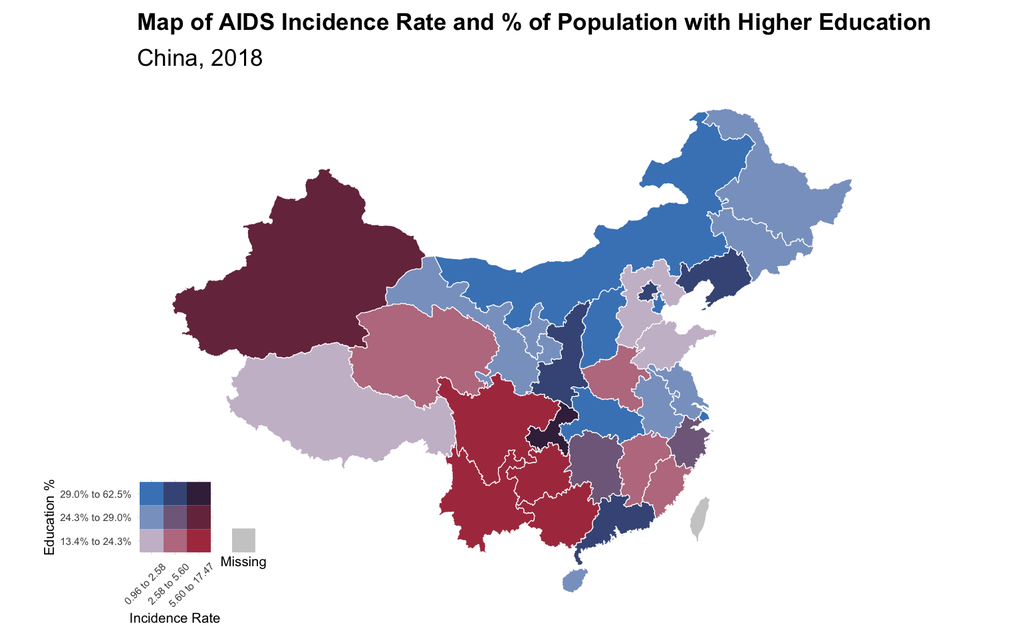

```r
## Bivariate map 1-----------
# Create the Bivariate Color Scale-------
# Create 3 buckets for rate
quantiles_rate0 <- hiv %>%
  pull(RATE) %>%
  quantile(probs = seq(0, 1, length.out = 4))

quantiles_rate <- c(0.96, 2.58, 5.60, 17.47) # Manually set the breaks to distinguish outliers of rates

# Create 3 buckets for EDUCATION
quantiles_edu <- hiv %>%
  pull(EDUCATION) %>%
  quantile(probs = seq(0, 1, length.out = 4),na.rm = T)

# Create color scale that encodes two variables
# red for RATE and blue for EDUCATION
bivariate_color_scale <- tibble(
  "3 - 3" = "#3F2949", # high rate, high edu
  "2 - 3" = "#435786",
  "1 - 3" = "#4885C1", # low rate, high edu
  "3 - 2" = "#77324C",
  "2 - 2" = "#806A8A", # medium rate, medium edu
  "1 - 2" = "#89A1C8",
  "3 - 1" = "#AE3A4E", # high rate, low edu
  "2 - 1" = "#BC7C8F",
  "1 - 1" = "#CABED0" # low rate, low edu
) %>%
  gather("group", "fill")

# Join Color Codes to the Data---------
# cut into groups defined above and join RATE
hiv1 <- hiv %>%
  mutate(
    rate_quantiles = cut(RATE,breaks = quantiles_rate,include.lowest = TRUE),
    edu_quantiles = cut(EDUCATION,breaks = quantiles_edu, include.lowest = TRUE),
    # by pasting the factors together as numbers we match the groups defined
    # in the tibble bivariate_color_scale
    group = paste(as.numeric(rate_quantiles), "-",as.numeric(edu_quantiles))) %>%
  # we now join the actual hex values per "group"
  # so each municipality knows its hex value based on the his gini and avg
  # income value
  left_join(bivariate_color_scale, by = "group")

# Draw the Map------------
# Give hex value to missing variables
hiv1[is.na(hiv1$fill), "fill"] <- "#CCCCCC"
# Mapping
map <- ggplot(hiv1) +
  # use the "alpha hack" (as the "fill" aesthetic is already taken)
  scale_alpha(name = "",
              range = c(0.6, 0),
              guide = F) + # suppress legend
  # color municipalities according to their RATE / EDUCATION combination
  geom_sf(aes(fill = fill),
    # use thin white stroke for provinces
    color = "white",size = 0.2) +
  # as the sf object municipality_prod_geo has a column with name "fill" that
  # contains the literal color as hex code for each municipality, we can use
  # scale_fill_identity here
  scale_fill_identity() +
  # add titles
  labs(x = NULL,
       y = NULL,
       title = "Map of AIDS Incidence Rate and % of Population with Higher Education",
       subtitle = "China, 2018") +
  # add the theme
  theme_map() +
  theme(plot.title = element_text(color = "black", face = "bold",
                                  size = 12, vjust = 1),
        plot.subtitle = element_text(color = "black",
                                     size = 12, vjust = 1))

# Draw the Legend--------
# separate the groups
color_scale <- bivariate_color_scale %>%
  separate(group, into = c("RATE", "EDUCATION"), sep = " - ") %>%
  mutate(RATE = as.factor(RATE),
         EDUCATION = as.factor(EDUCATION))
color_scale <- color_scale %>%
  mutate(RATE = factor(RATE, 1:3, c("0.96 to 2.58", "2.58 to 5.60", "5.60 to 17.47")),
         EDUCATION= factor(EDUCATION, 1:3, c("13.4% to 24.3%", "24.3% to 29.0%", "29.0% to 62.5%")))

# Draw legend
legend <- ggplot() +
  geom_tile(
    data = color_scale,
    mapping = aes(x = RATE, y = EDUCATION, fill = fill)) +
  scale_fill_identity() +
  labs(x = "Incidence Rate",
       y = "Education %")+
  theme_minimal(base_size=6.5) +
  theme(
    axis.title = element_text(size = 7),
    axis.text.x = element_text(vjust = 0.7, hjust = 0.7, angle = 45)
  ) +
  # quadratic tiles
  coord_fixed()

# Add Missing Legend------------
legend_miss <- ggplot() +
  geom_tile(data = color_scale[1,],
    mapping = aes(x = RATE, y = EDUCATION, fill = "#CCCCCC")) +
  scale_fill_identity() +
  labs( y = "   ",
    x = "Missing")+
  theme_map() +
  theme(
    axis.title = element_text(size = 7))

# Combine Map and Legends
ggdraw() +
  draw_plot(map, 0, 0, 1, 1) +
  draw_plot(legend, 0.0005, 0.001, 0.25, 0.25) +
  draw_plot(legend_miss, 0.20, 0.081, 0.0647, 0.1074)
```

- Overall, among regions with lower average education level (*red and pink*), most had high incidence rates (West part). Among regions with higher average education level(*blue and light blue*), most had low incidence rate (North-east). It indicated that education may be an effect factor of AIDS incidence rate.
- The High-High cluster region had low education and high incidence rate, indicates that education may be able to explain some of the clustering and high incidence rate
- However the Low-Low cluster region yielded a converse pattern, which were low in both education and incidence rate
- Only one province (Chongqing, in *dark purple* in the middle) had high education but was also high in incidence rate. It is possible that this province was infected by the nearby high incidence cluster
- Suggest a negative relationship

## 6.2 Bivariate Map for `RATE` and `HEALTHCARE`

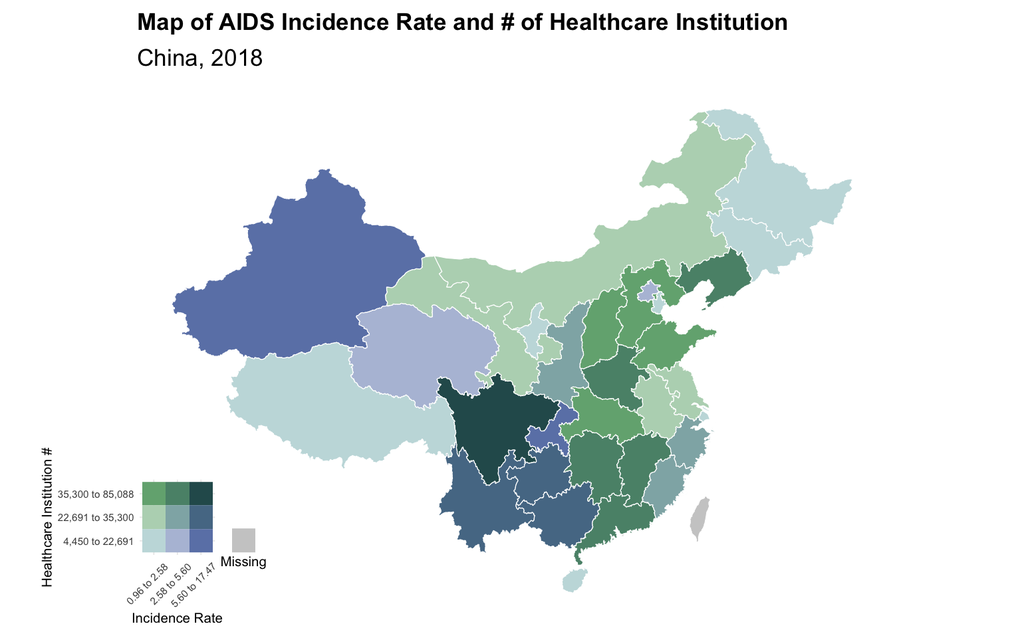

```r
# create 3 buckets for HEALTHCARE
quantiles_health <- hiv %>%
  pull(HEALTHCARE) %>%
  quantile(probs = seq(0, 1, length.out = 4),na.rm = T)

# create color scale that encodes two variables
# blue for RATE and green for HEALTHCARE
bivariate_color_scale2 <- tibble(
  "3 - 3" = "#2A5A5B", # high rate, high healthcare
  "2 - 3" = "#5A9178",
  "1 - 3" = "#73AE80", # low rate, high healthcare
  "3 - 2" = "#567994",
  "2 - 2" = "#90B2B3", # medium rate, medium healthcare
  "1 - 2" = "#B8D6BE",
  "3 - 1" = "#6C83B5", # high rate, low healthcare
  "2 - 1" = "#B5C0DA",
  "1 - 1" = "#C5DDDE" # low rate, low healthcare
) %>%
  gather("group", "fill")

# Join Color Codes to the Data----------------
# cut into groups defined above and join RATE
hiv2 <- hiv %>%
  mutate(
    rate_quantiles = cut(RATE,breaks = quantiles_rate,include.lowest = TRUE),
    health_quantiles = cut(HEALTHCARE,breaks = quantiles_health, include.lowest = TRUE),
    # by pasting the factors together as numbers we match the groups defined
    # in the tibble bivariate_color_scale
    group = paste(as.numeric(rate_quantiles), "-",as.numeric(health_quantiles))) %>%
  # we now join the actual hex values per "group"
  # so each municipality knows its hex value based on the his gini and avg
  # income value
  left_join(bivariate_color_scale2, by = "group")

# Draw the Map------------
# Give hex value to missing variables
hiv2[is.na(hiv2$fill), "fill"] <- "#CCCCCC"
# Mapping
map2 <- ggplot(hiv2) +
  # use the "alpha hack" (as the "fill" aesthetic is already taken)
  scale_alpha(name = "",
              range = c(0.6, 0),
              guide = F) + # suppress legend
  # color municipalities according to their RATE / HEALTHCARE combination
  geom_sf(aes(fill = fill),
          # use thin white stroke for provinces
          color = "white",size = 0.2) +
  # as the sf object municipality_prod_geo has a column with name "fill" that
  # contains the literal color as hex code for each municipality, we can use
  # scale_fill_identity here
  scale_fill_identity() +
  # add titles
  labs(x = NULL,
       y = NULL,
       title = "Map of AIDS Incidence Rate and # of Healthcare Institution",
       subtitle = "China, 2018") +
  # add the theme
  theme_map() +
  theme(plot.title = element_text(color = "black", face = "bold",
                                  size = 12, vjust = 1),
        plot.subtitle = element_text(color = "black",
                                     size = 12, vjust = 1))

# Draw the Legend-----------
# separate the groups
color_scale2 <- bivariate_color_scale2 %>%
  separate(group, into = c("RATE", "HEALTHCARE"), sep = " - ") %>%
  mutate(RATE = as.factor(RATE),
         HEALTHCARE = as.factor(HEALTHCARE))
color_scale2 <- color_scale2 %>%
  mutate(RATE = factor(RATE, 1:3, c("0.96 to 2.58", "2.58 to 5.60", "5.60 to 17.47")),
         HEALTHCARE= factor(HEALTHCARE, 1:3, c("4,450 to 22,691", "22,691 to 35,300", "35,300 to 85,088")))

# Draw legend
legend2 <- ggplot() +
  geom_tile(
    data = color_scale2,
    mapping = aes(x = RATE, y = HEALTHCARE, fill = fill)) +
  scale_fill_identity() +
  labs(x = "Incidence Rate",
       y = "Healthcare Institution #")+
  theme_minimal(base_size = 6.5) +
  theme(
    axis.title = element_text(size = 7),
    axis.text.x = element_text(vjust = 0.7, hjust = 0.7, angle = 45)
  ) +
  # quadratic tiles
  coord_fixed()

# Combine Map and Legend
ggdraw() +
  draw_plot(map2, 0, 0, 1, 1) +
  draw_plot(legend2, 0.0005, 0.001, 0.25, 0.25) +
  draw_plot(legend_miss, 0.20, 0.081, 0.0647, 0.1074)
```

- This map does not show a clear association between two variables as the prior one, the colors are spread-out
- It suggests that the count of health institutions may not be a significant covariate
- Directly using count as a covariate may not be appropriate (highly affected by land area, population and SES)

# 7. Aspatial Regression (Spatial Correlation)

## 7.1 Exploring bivariate correlation

First we wanted to visually explore the bivariate association between `HEALTHCARE` and `EDUCATION` to see if there is any collinearity between these two variables by checking the scatter plot. The scatter plot shows that there is **no obvious linear relationship** between `HEALTHCARE` and `EDUCATION`.

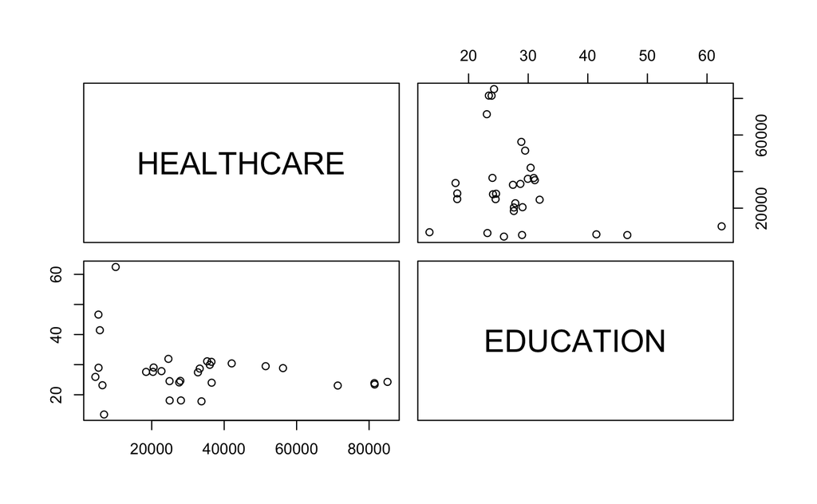

```r
# Test the collinearity of covariates
overall_case_rate <- sum(hiv$CASE) / sum(hiv$POP)
HIV <- hiv
st_geometry(HIV) <- NULL
vars <- c("HEALTHCARE", "EDUCATION")
pairs(HIV[,vars])
```

```r
# There is no linear relationship between HEALTHCARE and EDUCATION
```

## 7.2 Fitting unconditional (empty) model

```r
# Delete Hong kong, Macau and Taiwan in this regression analysis part for missing HEALTHCARE and EDUCATION information
HIV <- hiv[-c(11,14,27),]

# Create weights indicating the relative contribution of each tract to total population
HIV$wts <- HIV$POP/sum(HIV$POP,na.rm = T)

# Fitting crude/unconditional model
m0 <- lm(RATE ~ 1,
         data = HIV,
         weights = wts)
summary(m0)
```

```
Call:
lm(formula = RATE ~ 1, data = HIV, weights = wts)

Weighted Residuals:
    Min      1Q  Median      3Q     Max
-0.9829 -0.4277 -0.3009 -0.1112  3.1393

Coefficients:
            Estimate Std. Error t value Pr(>|t|)
(Intercept)   4.6245     0.8247   5.607  4.2e-06 ***
---
Signif. codes:  0 ‘***’ 0.001 ‘**’ 0.01 ‘*’ 0.05 ‘.’ 0.1 ‘ ’ 1

Residual standard error: 0.8247 on 30 degrees of freedom
```

- This output result indicates that the province-level mean of incident AIDS rate in China is significantly different from 0 (the p-value for intercept is < 0.0001).

## 7.3 Fitting conditional model with controlled variables

```r
m1 <- lm(RATE ~ HEALTHCARE+EDUCATION,
         data = HIV,
         weights = wts)
summary(m1)
```

```
Call:
lm(formula = RATE ~ HEALTHCARE + EDUCATION, data = HIV, weights = wts)

Weighted Residuals:
    Min      1Q  Median      3Q     Max
-1.1186 -0.3933 -0.2357  0.1451  2.9913

Coefficients:
              Estimate Std. Error t value Pr(>|t|)
(Intercept)  1.072e+01  4.450e+00   2.410   0.0228 *
HEALTHCARE  -4.789e-06  3.677e-05  -0.130   0.8973
EDUCATION   -2.181e-01  1.309e-01  -1.666   0.1069
---
Signif. codes:  0 ‘***’ 0.001 ‘**’ 0.01 ‘*’ 0.05 ‘.’ 0.1 ‘ ’ 1

Residual standard error: 0.8113 on 28 degrees of freedom
Multiple R-squared:  0.09692,   Adjusted R-squared:  0.03241
F-statistic: 1.502 on 2 and 28 DF,  p-value: 0.24
```

```r
# Both HEALTHCARE and EDUCATION are insignificant
```

This output result indicates that both `HEALTHCARE` and `EDUCATION` are not statistically significantly associate with `RATE`, but we can see the p-value for intercept dramatically increases from 4.2e-6 in previous crude model to 0.0228 in this conditional model, and the residual standard error also decreased from 0.8247 in previous crude model to 0.8113 in this conditional model. These changes may indicate that although `HEALTHCARE` and `EDUCATION` are insignificantly associate with `RATE`, they can somewhat explain the variation (heterogeneity) of the province-level incident AIDS rates in China.

## 7.4 Mapping residuals

We wanted to further explore the studentized residuals map for both the crude and conditional models to see if there is any difference between these two residuals maps by add the variables. We decided to use `style = sd` to create the maps because we wanted to detect potential outliers of residuals.

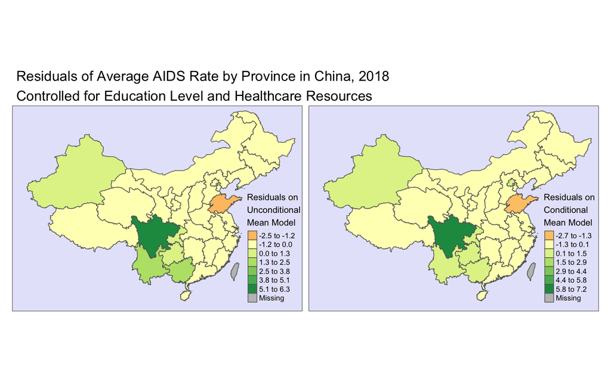

```r
# package MASS for calculating studentized residuals
HIV$m0_resids <- MASS::studres(m0)
HIV$m1_resids <- MASS::studres(m1)

# Add HIV dataset back to geodata to plot the regions with missing value
# 祖国统一万岁！(耶!!)
HIV_join <- HIV %>%
  dplyr::select(ADM1_PCODE, m0_resids, m1_resids)
st_geometry(HIV_join) <- NULL
map_residual <- province %>%
  left_join(HIV_join, by="ADM1_PCODE")

# style = 'sd' option in tm_fill(). In contrast to style = 'quantile',
# this will emphasize extreme outliers (high or low), which are locations
# where the model is particularly poor-fitting

# the residual maps for crude model and conditional model adjusted by HEALTHCARE and EDUCATION
tm_shape(map_residual) +
  tm_fill(c('m0_resids', 'm1_resids'),
          style = 'sd',
          palette = 'RdYlGn',
          title =
            c('Residuals on\nUnconditional\nMean Model','Residuals on\nConditional\nMean Model')) +
  tm_borders() +
  tm_layout(legend.position = c('RIGHT','bottom'),
            inner.margins = c(.05,0.05,0.025,0.025),
            legend.format = list(digits = 1),
            legend.title.size = 1 ,
            bg.color = 'lavender',
            main.title = 'Residuals of Average AIDS Rate by Province in China, 2018\nControlled for Education Level and Healthcare Resources',
            main.title.size = 1)
```

Although these two residuals maps are mostly similar, we can see that there are some minor changes of the residuals on Southwest China, which is the cluster area. This may indicate that `HEALTHCARE` and `EDUCATION` impact the `RATE` more in the clustering area with high incidence rate in Southwest China than other areas.

## 7.5 Moran’s I tests on lm models

Finally we used the Moran’s I tests to see if there is the existence of significant clustering for the residuals in the two models

```r
# Creating spatial neighbors
qnb <- poly2nb(HIV)
qnb[[31]] <- as.integer(27) # assign Hainan province, an island in China,
# to be neighbor of Guangdong province considering close distance and similar demographic characteristics

q_listw <- nb2listw(qnb, style = 'W') # row-standardized weights

# lm.morantest() function
lm.morantest(m0, listw = q_listw)
```

```
    Global Moran I for regression residuals

data:
model: lm(formula = RATE ~ 1, data = HIV, weights = wts)
weights: q_listw

Moran I statistic standard deviate = 3.6798, p-value = 0.0001167
alternative hypothesis: greater
sample estimates:
Observed Moran I      Expectation         Variance
      0.39952035      -0.03264031       0.01379246
```

```r
lm.morantest(m1, listw = q_listw)
```

```
    Global Moran I for regression residuals

data:
model: lm(formula = RATE ~ HEALTHCARE + EDUCATION, data = HIV, weights = wts)
weights: q_listw

Moran I statistic standard deviate = 2.7906, p-value = 0.002631
alternative hypothesis: greater
sample estimates:
Observed Moran I      Expectation         Variance
      0.27753869      -0.04590872       0.01343454
```

```r
# the p-values in both of the moran tests are < 0.05
# indicating there are significant clusterings for the residuals both in crude model and conditional model
```

[output not shown]

# 8. Discussion and Limitation

Please refer to our poster for further discussions. Thank you!